# State of the AnVIL 2024

Main analysis

Kate Isaac, Elizabeth Humphries, & Ava Hoffman

2024-05-13

```r
library(googlesheets4)
library(tidyverse)
library(magrittr) #for %<>%
library(here)
library(grid) #for Grobs and unit()
```

# Read in data

Data were read in via a Google Sheet on the AnVIL Team Drive.

**Import details**

The google sheet we are reading in is stored in an AnVIL Google drive folder `State of the AnVIL 2024`. Its permissions are restricted such that only people with access can open with the link. Using `gs4_auth()` to authorize my google account before running this code, I needed to change the `scopes` argument, specifically `scopes=spreadsheets.readonly` was necessary.

In this google sheet, each question is a column, and each response to the survey is a row. If the respondant wasn’t asked or didn’t answer a specific question, there is an NA in the corresponding row/column.

# Clean data

**Note:** Every code block in this section edits the `resultsTidy` data frame and should be run before plotting within the `# Insights` section below. Subsections are marked according to which Insight they are related to, but cleaning steps like identifying the user type are important for most every plot.

## Set Column Names

We set the column names to simplified column names (e.g., that help us select related columns for various analyses) by reading in a codebook (`data/codebook.txt`).

**Simplifying column names details**

**Description of variable definitions and steps**

We have a codebook that is a tab delmited file and has 4 columns, and each row represents a question in the survey. The first column lists a/the question from the survey (`SurveyColNames`); the second column lists a corresponding simplified column name for that survey question (`SimplifedColNames`); the third column describes the variable format (`VariableFormat`), e.g, is it a double, or a character; the fourth column gives a lengthier description of the question (`Description`), e.g., who was asked it, what possible answers are, etc.

This code block reads in that codebook and specifically selects the `SimplifiedColNames` column. It then renames the column names of the raw results from the google sheet (where each question is a column) with these simplified column names.

```r
simplifiedColNames <-
  read_delim(here("data/codebook.txt"),
             delim = "\t",
             col_select = SimplifiedColNames)
resultsTidy <-
  resultsRaw %>% `colnames<-`(unlist(simplifiedColNames))
```

## Keep last response if duplicated according to email (if email provided)

Choosing to select the last response because the respondent may have spent more time thinking about how they wanted to respond after their initial response.

**Filtering duplicated responses details**

**Description of variable definitions and steps**

- The `table` function tabulates the number of occurrences, and we tell it to ignore literal NAs. Because providing an email was optional, we expect many NA responses. The `table` function, by ignoring NAs, will return the unique emails and the number of times each email was used. We store the tabulated results in the variable `tabulatedEmails`
- Using the `sum` function, we look to see how many emails/responses are provided more than once. `tabulatedEmails > 1` is returning a vector of TRUEs and FALSEs where TRUE means that there was more than one instance/count of a given email and FALSE means there wasn’t. The `sum` function in essence counts the number of TRUEs and if the `sum` is greater than 0, that means there is at least one duplicated email whose count is greater than 1.
- `duplicatedEmails` reports which emails are duplicated by using the tabulated/table of emails. First it identifies which emails were observed more than once, using the `which` function, and uses the indices returned from that to index the `names` of the tabulated emails, grabbing the specific emails.
- We want to know which entries from the overall survey responses to remove for each duplicated email. Ideally, we want to remove the responses all at the same time or go backwards removing one at a time, because we don’t want to affect downstream indices. The approach here, keeps track of all the indices of interest and removed them at the same time.
  - Therefore, we’ll use `lapply` to loop through the duplicated emails (`duplicatedEmails`) and grab the index for survey responses associated with that email address (`which(resultsTidy$Email == duplicatedEmails[x])`).
  - However, we want to keep the last survey response for each duplicated email. Therefore, we wrap that `which` function in `head(_,-1 )` function so that it grabs all indices except the last one.
  - Finally, we `unlist` the indices so that there’s a single vector associated with indices for any duplicated email responses to be removed `IDXs_to_remove`. And since we want to remove them all at the same time, we subset `resultsTidy`, grabbing every row except those in `IDXs_to_remove`, as denoted by the `-`.

```r
tabulatedEmails <- table(resultsTidy$Email, useNA = "no")

if (sum(tabulatedEmails > 1) > 0) {
  duplicatedEmails <-
    names(tabulatedEmails)[which(tabulatedEmails > 1)]
  IDXs_to_remove <-
    unlist(lapply(1:length(duplicatedEmails), function(x)
      head(
        which(resultsTidy$Email == duplicatedEmails[x]),-1
      )))
  resultsTidy <- resultsTidy[-IDXs_to_remove, ]
}

nrow(resultsTidy)
```

```
## [1] 50
```

## Identify type of user

The first question of the poll asks respondents to describe their current usage of the AnVIL and allows us to categorize respondents as potential or current users of the AnVIL.

**Question and possible answers**

> How would you describe your current usage the AnVIL platform?

Possible answers include:

- For completed/long-term projects (e.g., occasional updates/maintenance as needed)
- For ongoing projects (e.g., consistent project development and/or work)
- For short-term projects (e.g., short, intense bursts separated by a few months)
- I do no currently use the AnVIL, but have in the past
- I have never heard of the AnVIL
- I have never used the AnVIL, but have heard of it.

The first three possible answers represent current or returning AnVIL users. The last three possible answers represent potential AnVIL users.

**Identifying user type details**

**Description of variable definitions and steps**

We use `case_when` to evaluate the response in the `CurrentUsageDescription` column and assign a corresponding, simplified label of “CurrentUser” or “PotentialUser’. In other words we translate the given response to a user label. Using the `case_when` as the internal nested function of the `mutate` function, means that the translation is then saved in a new column, `UserType`.

```r
resultsTidy %<>%
  mutate(
    UserType = case_when(
      CurrentUsageDescription == "For ongoing projects (e.g., consistent project development and/or work)" ~ "CurrentUser",
      CurrentUsageDescription == "For completed/long-term projects (e.g., occasional updates/maintenance as needed)" ~ "CurrentUser",
      CurrentUsageDescription == "For short-term projects (e.g., short, intense bursts separated by a few months)" ~ "CurrentUser",
      CurrentUsageDescription == "I do not currently use the AnVIL, but have in the past" ~ "PotentialUser",
      CurrentUsageDescription == "I have never used the AnVIL, but have heard of it" ~ "PotentialUser",
      CurrentUsageDescription == "I have never heard of the AnVIL" ~ "PotentialUser"
    )
  ) %>%
  mutate(UserType = factor(UserType, levels = c("PotentialUser", "CurrentUser")))
```

## Institutional Affiliation: Synchronize Institution Names

Users were able to disclose their institutional affiliation using a free text response, therefore we needed to synchronize institution names (example: Johns Hopkins and Johns Hopkins University refer to the same institution, despite the difference in the free responses) and added simplified affiliation categories ([R1 University, R2 University, Community College, Medical Center or School, International Location, Research Center, NIH, Industry, Unknown] and [Research Intensive, Education Focused, and Industry & Other]). The first level of affiliation categories are notated in an institution specific codebook (`data/institution_codebook.txt`)

**Question and possible answers**

> What institution are you affiliated with?

Free response for answers

**Institutional affiliation syncronizations details**

This synchronization corrects for the various spellings and capitalizations used for the same institution (ex, Johns Hopkins and Johns Hopkins University refer to the same institution, despite the difference in the free responses).

**Description of variable definitions and steps**

We use a `recode()` within a `mutate()` to synchronize the institutional affiliations as necessary

```r
resultsTidy %<>%
  mutate(
    InstitutionalAffiliation =
      recode(
        InstitutionalAffiliation,
        "Broad" = "Broad Institute",
        "broad institute" = "Broad Institute",
        "CUNY School of Public Health; Roswell Park Comprehensive Cancer Center" = "City University of New York",
        "harvard" = "Harvard University",
        "Harvard Public Health" = "Harvard University",
        "Johns hopkins" = "Johns Hopkins",
        "Johns Hopkins University" = "Johns Hopkins",
        "OHSU" = "Oregon Health & Science University",
        "OHSU (Knight Center)" = "Oregon Health & Science University",
        "The Ohio State University" = "Ohio State University",
        "UCSC" = "University of California Santa Cruz",
        "univ. ca. santa cruz" = "University of California Santa Cruz",
        "university of California santa cruz" = "University of California Santa Cruz",
        "UMASS Chan Medical School" = "UMass Chan Medical School",
        "Umass Chan Medical School" = "UMass Chan Medical School",
        "Washington University in St Louis" = "Washington University in St. Louis",
        "yikongene" = "Yikon Genomics",
        "v" = "Unknown"
      )
  )
```

Elizabeth Humphries grouped institutional affiliations into a limited set of categories: R1 University, R2 University, Community College, Medical Center or School, International Location, Research Center, NIH, Industry, Unknown and we notated those groupings/labels within the `institution_codebook.txt` data file, . Grouping into limited institutional affiliation categories allows us to consolidate free answers for easier data visualization and identification of trends.

**Description of variable definitions and steps**

We use a `read_delim()` to read in the institution_codebook file, and select just the `InstitutionalAffiliation` and `InstitutionalType` columns (ignoring the column that specifies how institutions were entered by survey respondents). We then use a full_join by the `InstitutionalAffiliation` column to add an `InstitutionalType` column such that the category labels are now included as a new column, joining the appropriate values dependent upon the `InstitutionalAffiliation` column.

```r
institutionCodeBook <- read_delim(here("data/institution_codebook.txt"), delim="\t", col_select = c(InstitutionalAffiliation, InstitutionalType))

resultsTidy <- full_join(resultsTidy, institutionCodeBook, by = "InstitutionalAffiliation")
```

Here we even further simplify Institutional Affiliations to focus on Research Intensive, Education Focused, and Industry & Other

This groups R1 University, Research Center, Medical Center or School, and NIH as “Research Intensive”; R2 University & Community College as “Education Focused”; and Industry, International Location, or Unknown as “Industry & Other”.

```r
resultsTidy %<>%
  mutate(FurtherSimplifiedInstitutionalType =
           case_when(
             InstitutionalType == "R1 University" ~ "Research Intensive",
             InstitutionalType == "Research Center" ~ "Research Intensive",
             InstitutionalType == "Medical Center or School" ~ "Research Intensive",
             InstitutionalType == "NIH" ~ "Research Intensive",
             InstitutionalType == "R2 University" ~ "Education Focused",
             InstitutionalType == "Community College" ~ "Education Focused",
             InstitutionalType == "Industry" ~ "Industry & Other",
             InstitutionalType == "International Location" ~ "Industry & Other",
             InstitutionalType == "Unknown" ~ "Industry & Other"
           )
         )
```

## Highest degree attained

This question allowed more than one response, however, only one response selected two (PhD, MD), which we recoded to be MD/PhD. We simplify the possible responses to group attained or in progress degrees

**Question and possible answers**

> What is the highest degree you have attained?

Possible answers include (and multiple choices could be selected and would be comma separated if so)

- High school or equivalent
- Bachelor’s degree
- Master’s degree in progress
- Master’s degree
- PhD in progress
- PhD
- MD in progress
- MD
- Other (with free text entry)

**Degree recoding details**

**Description of variable definitions and steps**

Because multiple responses could be selected and those would be comma separated and because free text response was possible if other was selected, we need to tidy the data from this question. From visual inspection of the data, I see that the only time multiple responses were selected were for MD/PhD. No other’s were selected. So we’ll just recode “PhD, MD” to be “MD/PhD”

Let’s also set the factor levels to follow the general progress of degrees

```r
resultsTidy %<>%
  mutate(
    Degrees =
      factor(recode(Degrees, "PhD, MD" = "MD/PhD"), levels = c("High School or equivalent", "Bachelor's degree", "Master's degree in progress", "Master's degree", "PhD in progress", "PhD", "MD in progress", "MD", "MD/PhD")),
    FurtherSimplifiedDegrees = recode(Degrees,
                                      "Master's degree in progress" = "Master's degree (or in progress)",
                                      "Master's degree" = "Master's degree (or in progress)",
                                      "PhD in progress" = "PhD (or in progress)",
                                      "PhD" = "PhD (or in progress)",
                                      "MD/PhD" = "MD (MD, MD/PhD, or in progress)",
                                      "MD in progress" = "MD (MD, MD/PhD, or in progress)",
                                      "MD" = "MD (MD, MD/PhD, or in progress)"
                          )
  )
```

## Tool Knowledge and Comfort Separate from the AnVIL and on the AnVIL

We want to recode these responses to set the factor level/progression from Don’t know it, not at all comfortable, all the way to extremely comfortable and make corresponding integer comfort scores.

**Question and possible answers**

> How would you rate your knowledge of or comfort with these technologies (separate from the AnVIL)? How would you rate your knowledge of or comfort with these technologies (on the AnVIL)? How would you rate your knowledge of or comfort with these AnVIL data features? Shared technologies between these two questions include
- Jupyter Notebooks: `CurrentAnVILTechJupyterNotebooks` & `AllTechJupyterNotebooks`
- Bioconductor & RStudio: `CurrentAnVILTechRStudio` & `AllTechRStudio` + `AllTechBioconductor`
- Galaxy: `CurrentAnVILTechGalaxy` & `AllTechGalaxy`
- WDL Workflows / Workflows (e.g., WDL): `CurrentAnVILTechWDL` & `AllTechWorkflows`
- Containers: `CurrentAnVILTechContainers` & `AllTechContainers`
- Unix / Command Line: `CurrentAnVILTechCommandLine` & `AllTechCommandLine`

Technologies only asked separate from the AnVIL

- Python: `AllTechPython`
- R: `AllTechR`

Technologies/data features only asked with regards to the AnVIL

- Accessing controlled access datasets: `CurrentAnVILTechAccessData`
- DUOS (Data Use Oversight System): `CurrentAnVILTechDUOS`
- Terra on AnVIL (Workspaces): `CurrentAnVILTechTerra`
- TDR (Terra Data Repository): `CurrentAnVILTechTDR`

Possible answers for each of these questions include

- Don’t know it (0)
- Not at all comfortable (1)
- Slightly comfortable (2)
- Somewhat comfortable (3)
- Moderately comfortable (4)
- Extremely comfortable (5)

Notated possible “comfort scores” in parentheses next to each possible answer. We’ll add these as additional columns that now start with the word “Score_” but otherwise retain the column name, in case it’s helpful to still have the words (whose factor level we’ll set to reflect the progression of knowledge/comfort).

Responses are NA if the question wasn’t asked to the survey taker (e.g., they were a potential user and weren’t asked about technologies with regards to the AnVIL)

**Cleaning Comfort level/scores for various technologies and resources details**

It’s likely that someone who’s a program administrator will select don’t know for these…. should we remove them and see how average scores change?

**Description of variable definitions and steps**

We select the relevant columns (those that start with “CurrentAnVILTech” or “AllTech”) we want to work with. We don’t want them to be lists. The non-tidyverse way of doing this would be `unlist(as.character(resultsTidy$PotentialRankEasyBillingSetup))`. We can use the `unnest` tidyverse function with a `keep_empty = TRUE` argument so that it preserves the NULL values. Notice in the non-tidyverse way, we had to use `as.character` in order to preserve the null values. In the tidyverse way, we still have to use an as.character type change before the `unnest`, otherwise, we get an error that double and character values can’t be combined.

After the `unnest` we can use the `mutate` function to first work with these as factors (to set the progression we want from don’t know it all the way to extremely comfortable) and hten to make the replacements specified above for an integer score in place of the comfort level, placing these scores in new columns with names that begin with “Score_” and fill in the rest of the column name with the corresponding original column name.

```r
resultsTidy %<>%
  mutate(across(starts_with(c(
    "CurrentAnVILTech", "AllTech"
  )), as.character)) %>%
  unnest(starts_with(c("CurrentAnVILTech", "AllTech")), keep_empty = TRUE) %>%
  mutate(across(starts_with(c(
    "CurrentAnVILTech", "AllTech"
  )), ~ parse_factor(
    .,
    levels = c(
      "Don't know it",
      "Not at all comfortable",
      "Slightly comfortable",
      "Somewhat comfortable",
      "Moderately comfortable",
      "Extremely comfortable"
    )
  ))) %>%
  mutate(across(
    starts_with(c("CurrentAnVILTech", "ALLTech")),
    ~ case_when(
      . == "Don't know it" ~ 0,
      . == "Not at all comfortable" ~ 1,
      . == "Slightly comfortable" ~ 2,
      . == "Somewhat comfortable" ~ 3,
      . == "Moderately comfortable" ~ 4,
      . == "Extremely comfortable" ~ 5
    )
    ,
    .names = "Score_{.col}"
  ))
```

## Feature importance: Comparisons of rank of importance of features/resources between Current Users and Potential Users

We want to recode these responses to remove labels and make them integers.

**Question and possible answers**

> Rank the following features or resources according to their importance for your continued use of the AnVIL

> Rank the following features or resources according to their importance to you as a potential user of the AnVIL?
- Easy billing setup
- Flat-rate billing rather than use-based
- Free version with limited compute or storage
- On demand support and documentation
- Specific tools or datasets are available/supported
- Greater adoption of the AnVIL by the scientific community

We’re going to look at a comparison of the assigned ranks for these features, comparing between current users and potential users.

### Recode rank values

**Description of variable definitions and steps**

Columns of interest include

- PotentialRankEasyBillingSetup
- PotentialRankFlatRateBilling
- PotentialRankFreeVersion
- PotentialRankSupportDocs
- PotentialRankToolsData
- PotentialRankCommunityAdoption
- CurrentRankEasyBillingSetup
- CurrentRankFlatRateBilling
- CurrentRankFreeVersion
- CurrentRankSupportDocs
- CurrentRankToolsData
- CurrentRankCommunityAdoption

**Cleaning the feature importance ranks details**

**Description of variable definitions and steps**

We can use `starts_with` to select these columns, specifically focusing on the starts with “PotentialRank” and “CurrentRank”. When we made simplified names for the columns, these are the only twelve that start like that.

Either the 6 CurrentRank or the 6 PotentialRank were asked to each survey taker which means that we expect NULL values in these columns since not every survey taker will have answered all of these questions.

We want to recode the following values

- Replace 1 (Most important in this list) with 1
- Replace 6 (Least important in this list) with 6

Before we can do that, we first need to change the type of the columns in several ways. We don’t want them to be lists. The non-tidyverse way of doing this would be `unlist(as.character(resultsTidy$PotentialRankEasyBillingSetup))`. We can use the `unnest` tidyverse function with a `keep_empty = TRUE` argument so that it preserves the NULL values. Notice in the non-tidyverse way, we had to use `as.character` in order to preserve the null values. In the tidyverse way, we still have to use an as.character type change before the `unnest`, otherwise, we get an error that double and character values can’t be combined.

After the `unnest` we can use the `recode` function to make the replacements specified above. And then we go ahead and change the type from character to integer so that we can compute average rank & plot them more easily. There will be a warning that NAs are introduced by coercion when we change the type to integer. So we add a replacement in the `recode`, changing “NULL” to the `NA_character_`

```r
resultsTidy %<>%
  mutate(across(starts_with(c(
    "PotentialRank", "CurrentRank"
  )), as.character)) %>%
  unnest(starts_with(c("PotentialRank", "CurrentRank")), keep_empty = TRUE) %>%
  mutate(across(
    starts_with(c("PotentialRank", "CurrentRank")),
    ~ recode(
      .x,
      "1 (Most important in this list)" = "1",
      "6 (Least important in this list)" = "6",
      "NULL" = NA_character_
    )
  )) %>%
  mutate(across(starts_with(c(
    "PotentialRank", "CurrentRank"
  )), as.integer))
```

## Training Modality Preference

We want to recode these responses to remove labels and make them integers.

**Question and possible answers**

> Please rank how/where you would prefer to attend AnVIL training workshops.

Possible answers include

- On-site at my institution: `AnVILTrainingWorkshopsOnSite`
- Virtual: `AnVILTrainingWorkshopsVirtual`
- Conference (e.g., CSHL, AMIA): `AnVILTrainingWorkshopsConference`
- AnVIL-specific event: `AnVILTrainingWorkshopsSpecEvent`
- Other: `AnVILTrainingWorkshopsOther`

The responses are stored in the starts with `AnVILTrainingWorkshops` columns

**Cleaning the training modality ranks details**

**Description of variable definitions and steps**

We can use `starts_with` to select these columns, specifically focusing on the starts with “AnVILTrainingWorkshops”. These are the only 5 that start like that when we made simplified column names.

We want to recode the following values

- Replace 1 (Most preferred in this list) with 1
- Replace 5 (Least preferred in this list) with 5

Before we can do that, we first need to change the type of the columns in several ways. We don’t want them to be lists. We can use the `unnest` tidyverse function with a `keep_empty = TRUE` argument so that it preserves any NULL values, but first we have to use an `as.character` type change before the `unnest`, otherwise, we get an error that double and character values can’t be combined.

After the `unnest` we can use the `recode` function to make the replacements specified above. And then we go ahead and change the type from character to integer so that we can compute average rank & plot them more easily. There will be a warning that NAs are introduced by coercion when we change the type to integer. So we add a replacement in the `recode`, changing “NULL” to the `NA_character_`

```r
resultsTidy %<>%
  mutate(across(starts_with(
    "AnVILTrainingWorkshops"), as.character)) %>%
  unnest(starts_with("AnVILTrainingWorkshops"), keep_empty = TRUE) %>%
  mutate(across(
    starts_with("AnVILTrainingWorkshops"),
    ~ recode(
      .x,
      "1 (Most preferred in this list)" = "1",
      "5 (Least preferred in this list)" = "5",
      "NULL" = NA_character_
    )
  )) %>%
  mutate(across(starts_with("AnVILTrainingWorkshop"), as.integer))
```

## Simplified experience status for various research categories (clinical, human genomics, non-human genomics)

Want to add three columns that act as flags reporting if the respondent is

- experienced with clinical research, specifically either moderately or extremely experienced in working with human clinical data
- experienced with human genomics research, specifically is moderately or extremely experienced in working with human genomics data
- experienced with non-human genomics research expert, specifically is moderately or extremely experienced in working with non-human genomics data

We will use this information later to subset responses when considering popular tools or datasets.

**Question and possible answers**

> How much experience do you have analyzing the following data categories?

The three research categories people are asked about include

- Human Genomic
- Non-human Genomic
- Human Clinical

Possible answers include

- Not at all experienced
- Slightly experienced
- Somewhat experienced
- Moderately experienced
- Extremely experienced.

**Setting research category experience flag details**

**Description of variable definitions and steps**

We use a `mutate` together with 3 `case_when`’s.

- If the `HumanClinicalExperience` column response is “Moderately experienced” or “Extremely experienced”, we mark that respondent as a human clinical research expert in the `clinicalFlag` column (`TRUE`). Otherwise, we mark a `FALSE` to signify they are not a clinical research expert.
- If the `HumanGenomicExperience` column response is “Moderately experienced” or “Extremely experienced”, we mark that respondent as a human genomic research expert in the `humanGenomicFlag` column (`TRUE`). Otherwise, we again mark a `FALSE` to signify not an expert.
- If the `NonHumanGenomicExperience` column response is “Moderately experienced” or “Extremely experienced”, we mark that respondent as a non-human genomic research expert in the `nonHumanGenomicFlag` column (`TRUE`). Otherwise, we again mark a `FALSE` to signify not an expert.

```r
resultsTidy %<>%
  mutate(
  clinicalFlag = case_when(
           HumanClinicalExperience == "Moderately experienced" | HumanClinicalExperience == "Extremely experienced" ~ TRUE,
           .default = FALSE
         ),
  humanGenomicFlag = case_when(
           HumanGenomicExperience == "Moderately experienced" | HumanGenomicExperience == "Extremely experienced" ~ TRUE,
           .default = FALSE
         ),
  nonHumanGenomicFlag = case_when(NonHumanGenomicExperience == "Moderately experienced" | NonHumanGenomicExperience == "Extremely experienced" ~ TRUE,
          .default = FALSE)
  )
```

# Insights

## Identify type of user

**Takeaway:** Of the `50` responses, `22` were current users and `28` were potential users. The majority of current users belonged to the group who use the AnVIL for ongoing projects while the majority of potential users were evenly split between those who have never used the AnVIL (but have heard of it) and those who used to previously use the AnVIL, but don’t currently.

**Potential Follow-ups:**

- Look to see if those potential users who previously used to use the AnVIL show similarity in overall trends with the rest of the potential users
- Directly ask why they no longer use the AnVIL (Elizabeth mentioned the possiblity that the AnVIL is sometimes used in courses or workshops and students may not use it after that)

### Prepare and plot the data

**Description of variable definitions and steps**

First, we group the data by the assigned UserType labels/categories and their related more detailed descriptions. Then we use `summarize` to count the occurances for each of those categories. We use a mutate statement to better fit the detailed descriptions on the plot. We then send this data to ggplot with the count on the x-axis, and the usage descriptions on the y-axis (ordered by count so highest count is on the top). We fill with the usertype description we’ve assigned. We manually scale the fill to be AnVIL colors and specify we want this to be a stacked bar chart. We then make edits for the theme and labels and finally add a geom_text label for the count next to the bars before we save the plot.

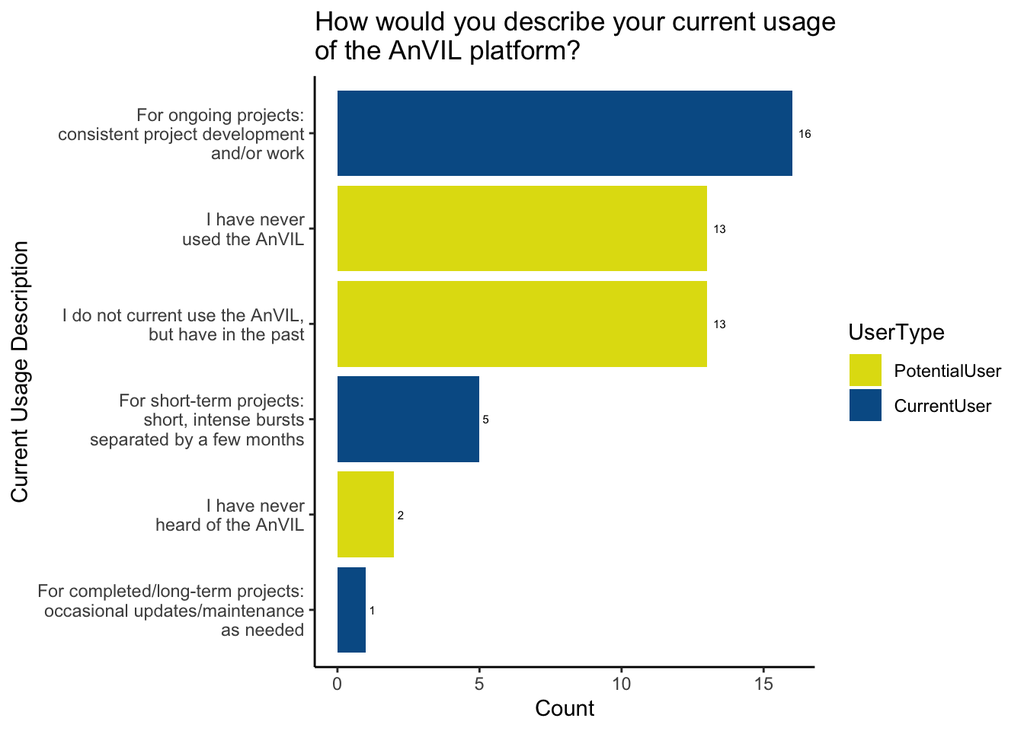

## Demographics: Institutional Affiliation

**Takeaway:**

### Prepare and plot the data

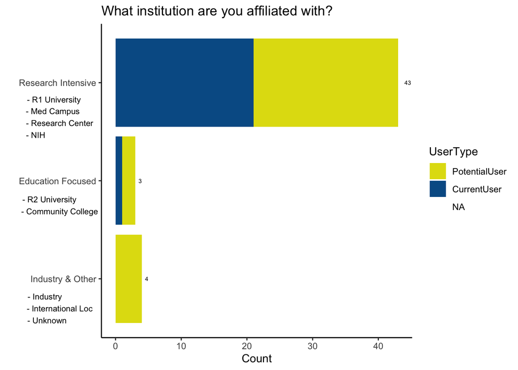

## Demographics: Highest Degree Attained

**Takeaway:**

### Prepare and plot the data

**Description of variable definitions and steps**

First we use `group_by()` to select`Degrees` and `UserType` in conjunction with `summarize( = n())` to add counts for how many of each combo are observed in the data.

Then we send this data to ggplot and make a bar chart with the x-axis representing the degrees (`reorder`ed by the count number such that higher counts are first (and the sum) because otherwise the 2 MDs are located after the high school and master’s in progress bars (1 each)). The y-axis represents the count, and the fill is used to specify user type (current or potential AnVIL users). We use a stacked bar chart and include labels above each bar of the total sum for that degree type.

Used [this stackoverflow post to label sums above the bars](https://stackoverflow.com/questions/30656846/draw-the-sum-value-above-the-stacked-bar-in-ggplot2)

and used [this stackoverflow post to remove NA from the legend](https://stackoverflow.com/questions/45493163/ggplot-remove-na-factor-level-in-legend)

The rest of the changes are related to theme and labels and making sure that the numerical bar labels aren’t cut off on the top.

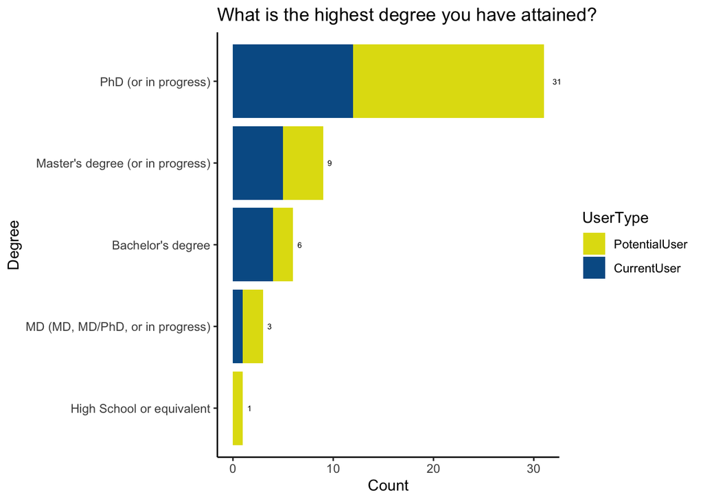

## Experience: Genomics and Clinical Research Experience

**Takeaway:**

### Prepare and plot the data

**Description of variable definitions and steps for preparing the data**

Here we select the columns containing answers for each data category: `HumanGenomicExperience`, `HumanClinicalExperience`, and `NonHumanGenomicExperience`. We also select `UserType` in case we want to split user type out at all in viewing the data. We use a `pivot_longer` to make a long dataframe that can be grouped and groups counted. The category/column names go to a new column, `researchType` and the values in those columns go to a new column `experienceLevel`. Before we use group by and count, we set the factor level on the new `experienceLevel` column to match the progression from not at all experienced to extremely experienced, and we rename the research categories so that the words have spaces, and we say research instead of experience. Then we use `group_by` and `summarize` to add counts for each combination of research category, experience level, and usertype. These counts are in the new `n` column.

**Description of variable definitions and steps for plotting the bar graph**

We didn’t observe big differences between current and potential users, so we believe this grouped plot is useful for understanding the community as a whole.

This bar plot has the experience level on the x-axis, the count on the y-axis, and fills the bars according to the experience level (though the fill/color legend is turned off by setting legend.position to none). We facet the research category type and label the bars. We keep a summary stat and sum function and after_stat(y) for the label since the data has splits like usertype that we’re not visualizing here.

We adjust various aspects of the theme like turning off the grid and background and rotating the x-tick labels and changing the x- and y-axis labels. We also slightly widen the left axis so that the tick labels aren’t cut off.

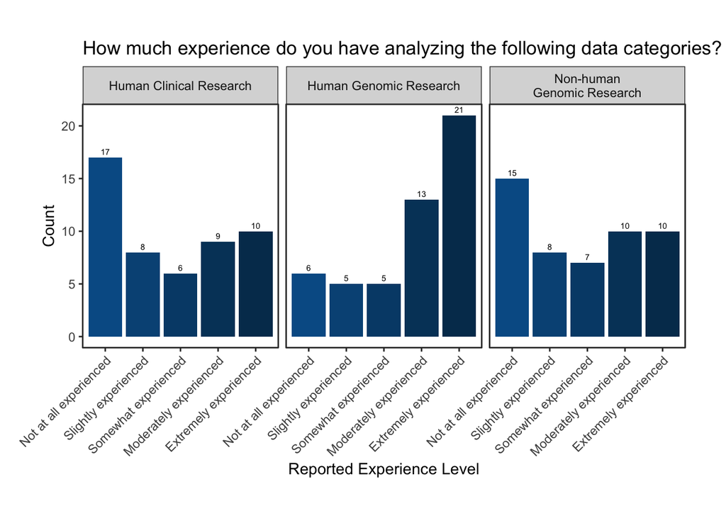

## Experience: Controlled Access Datasets

**Takeaway:**

**Question and possible answers**

> What large, controlled access datasets do you access or would you be interested in accessing using the AnVIL?
- All of Us*
- Centers for Common Disease Genomics (CCDG)
- The Centers for Mendelian Genomics (CMG)
- Clinical Sequencing Evidence-Generating Research (CSER)
- Electronic Medical Records and Genomics (eMERGE)
- Gabriella Miller Kids First (GMKF)
- Genomics Research to Elucidate the Genetics of Rare Diseases (GREGoR)
- The Genotype-Tissue Expression Project (GTEx)
- The Human Pangenome Reference Consortium (HPRC)
- Population Architecture Using Genomics and Epidemiology (PAGE)
- Undiagnosed Disease Network (UDN)
- UK Biobank*
- None
- Other (Free Text Response)

Since this is a select all that apply question, we expect that there will be multiple responses that are comma separated. The free text responses will likely need recoded as well. The responses are in the `AccessWhichControlledData` column.

### Prepare and plot the data

**Description of variable definitions and steps for preparing the data**

Making a function `prep_df_whichData()` since we’ll be using this workflow a few times for different subsets of the data, because we want to be able to differentially display the data based on the experience status (experienced with clinical research, human genomics research, etc.) of the person saying they’d like access to the data.

We want to color the bars based on whether or not the controlled access dataset is available on the AnVIL currently. We create a dataframe `onAnVILDF` to report this. Used the [AnVIL dataset catalog/browser](https://explore.anvilproject.org/datasets) to find out this information. However, HPRC and GREGoR don’t show up in that resource, but are both available per these sources: [Announcement for HPRC](https://anvilproject.org/news/2021/03/11/hprc-on-anvil), [Access for HPRC](https://anvilproject.org/data/consortia/HPRC), [Access for GREGoR](https://anvilproject.org/data/consortia/GREGoR). Both GMKF and TCGA are data hosted on other NCPI platforms that are accessible via AnVIL because of interoperability. (See: https://www.ncpi-acc.org/ and https://ncpi-data.org/platforms). We list these as non-AnVIL hosted since while accessible, they are not AnVIL hosted and inaccessible without NCPI. Finally, UDN is described as non-AnVIL hosted as it is in the Data submission pipeline and not yet available.

We’ll join this anvil-hosted or not data with the actual data at the end.

We then use `pivot_longer` to grab these columns we just made and put the column names in a new column `WhichChoice` and the values in the each column to a new column `whichControlledAccess`. We drop all the NAs in this new `whichControlledAccess` column (and there’s a lot of them there)…

Then we group by the new `whichControlledAccess` column and summarize a count for how many there are for each response.

Then we pass this to a mutate and recode function to simplify the fixed responses to be just their acronyms, to remove asterisks (that let the survey respondent know that that dataset wasn’t available because of policy restrictions), and to recode the free text responses (details below in “Notes on free text response recoding”).

We use a `left_join()` to join the cleaned data with a dataframe that specifies whether that dataset is currently available on the AnVIL or not. It’s a left join rather than a full join so it’s only adding the annotation for datasets that are available in the results.

Finally, we return this subset and cleaned dataframe so that it can be plotted.

**Additional notes on free text response recoding**

- “Being able to pull other dbGap data as needed.” –> We recoded this to be an “Other”
- “GnomAD and ClinVar” –> GnomAD and ClinVar are not controlled access datasets so we recoded that response to be “None”
- “Cancer omics datasets” –> We recoded this to be an “Other”
- “TCGA” –> This response was left as is since there is a controlled access tier.

**Description of variable definitions and steps for preparing the data continued**

Here we set up 4 data frames for plotting

- The first uses all of the responses and sends them through the `prep_df_whichData()` function to clean the data for plotting to see which controlled access datasets are the most popular.
- The second filters to grab just the responses from those experienced in clinical research using the `clinicalFlag` column (described earlier in the Clean Data -> Simplified experience status for various research categories (clinical, human genomics, non-human genomics) subsection)
- The third filters to grab just the responses from those experienced in human genomic research using the `humanGenomicFlag` column (described earlier in the Clean Data -> Simplified experience status for various research categories (clinical, human genomics, non-human genomics) subsection)
- The fourth filters to grab just the responses from those experienced in non-human genomic research using the `nonHumanGenomicFlag` column (described earlier in the Clean Data -> Simplified experience status for various research categories (clinical, human genomics, non-human genomics) subsection)

**Description of variable definitions and steps for plotting the bar graphs**

Also have a function here because it’s the same plotting steps for each just changing the subtitle and which dataframe is used as input.

This takes the input dataframe and plots a bar plot with the x-axis having the controlled access datasets listed (reordering the listing based off of the count so most popular is on the left), the count number/popularity of requested is on the y-axis, and the fill is based on whether the dataset is available on AnVIL or not.

We change the theme elements like removing panel borders, panel background, and panel grid, and rotate the x-axis tick labels. We add an x- and y- axis label and add a title (and subtitle if specified - which it will be when we’re looking at just a subset like those who are experienced with clinical data)

We also add text labels above the bars to say how many times each dataset was marked/requested. Note that we have to use the after_stat, summary, and sum way of doing it again because we use recoding and if we want the labels to be accurate, it has to capture every time we’ve recoded things to be the same after we used group_by and summarize to count before we recoded. It uses `coord_cartesian(clip = “off”) so these bar text labels aren’t cut off and finally returns the plot.

We call this function 4 times

- once for all the data (and don’t use a subtitle)
- next for just those experienced with clinical data (using a subtitle to specify this)
- next for just those experienced with human genomic data (using a subtitle to specify this)
- and finally for just those experienced with non-human genomic data (using a subtitle to specify this)

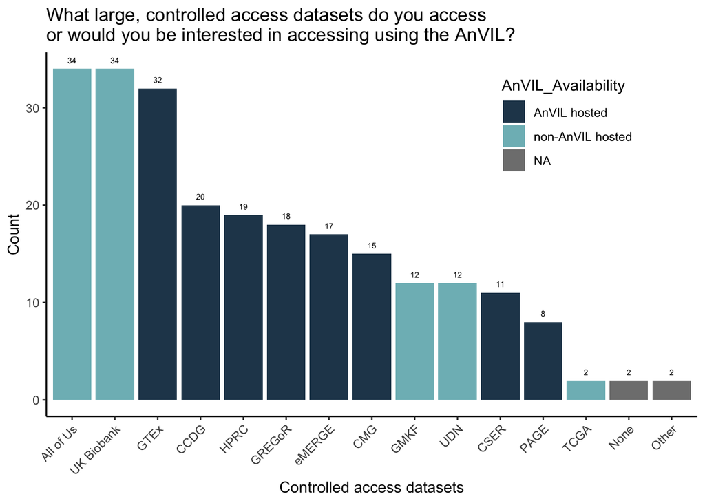

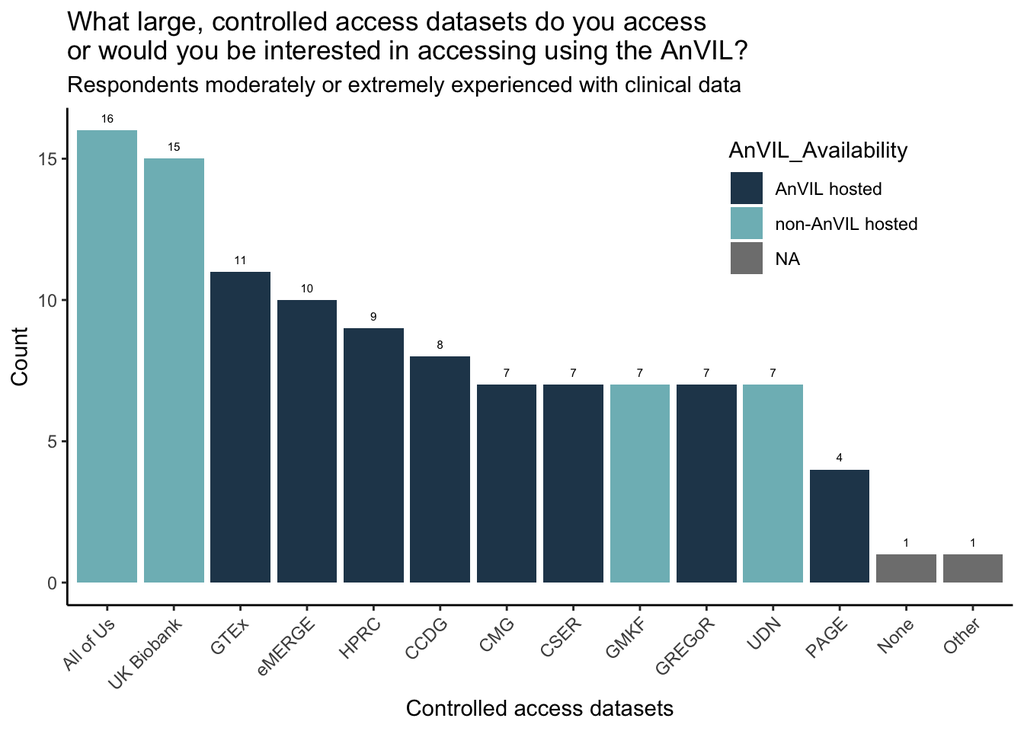

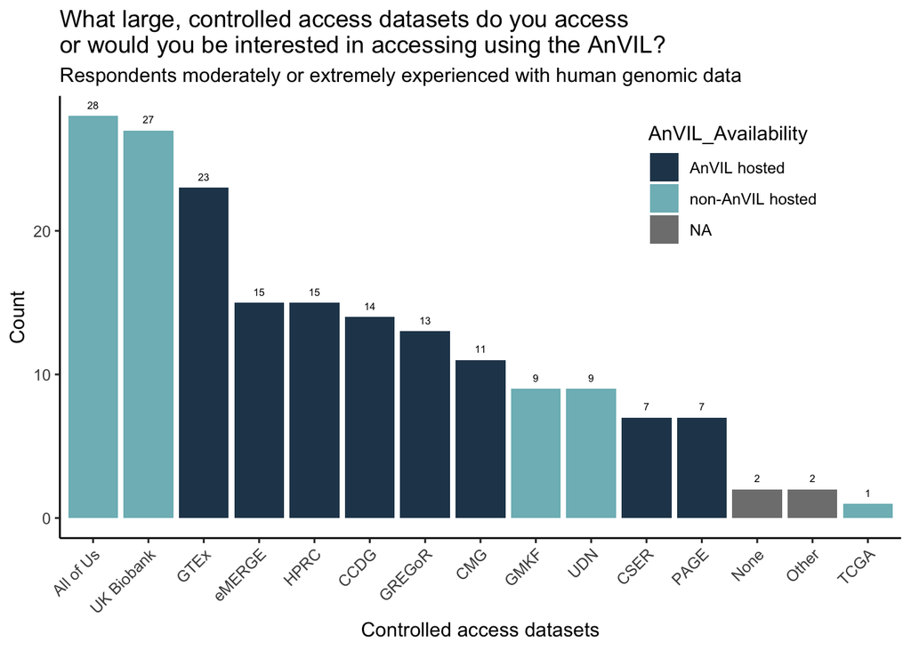

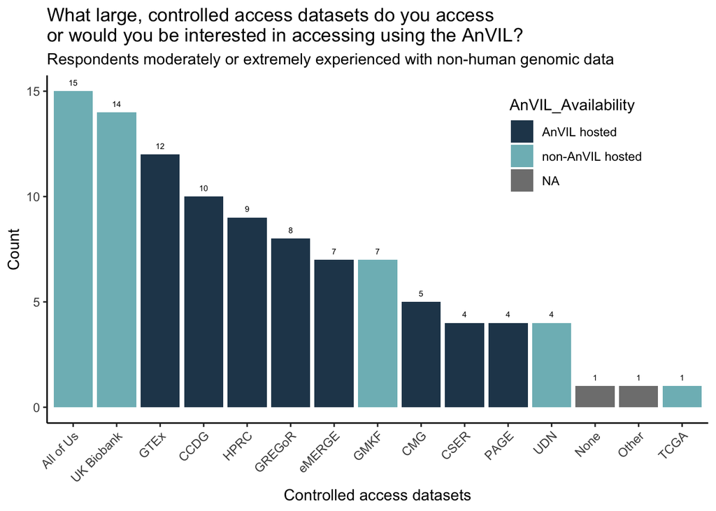

## Experience: Tool & Resource Knowledge/Comfort level

**Takeaway:**

### Prepare and plot the data

**Description of variable definitions and steps for preparing the data**

**Description of variable definitions and steps for plotting the dumbbell like plot**

Used [this stackoverflow response](https://stackoverflow.com/a/72309061) to get the values for the `scale_shape_manual()`

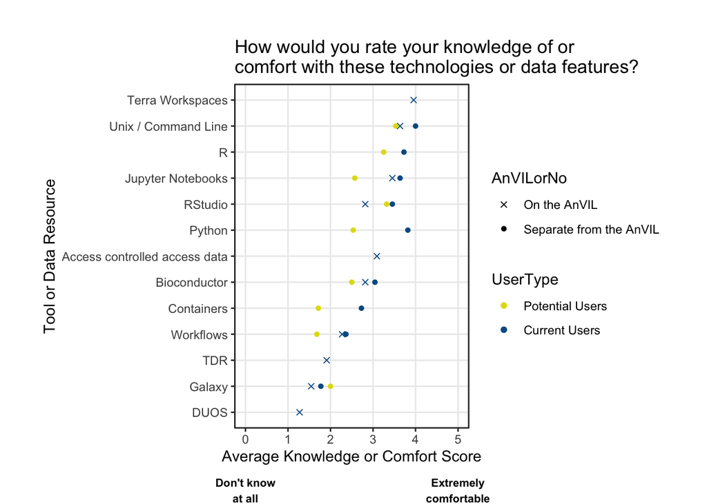

## Awareness: AnVIL Demos

**Takeaway:**

## Awareness: AnVIL Support Forum

**Takeaway:**

## Preferences: Feature importance for current vs potential users

**Takeaway:**

### Prepare and plot the data

Average rank is total rank (sum of given ranks) divided by number of votes (number of given ranks)

**Description of variable definitions and steps for preparing the data**

We make two different dataframes that find the total ranks (column name: `totalRank`) and avg ranks (column name: `avgRank`) for each future and then row bind (`bind_rows`) these two dataframes together to make `totalRanksdf`. The reason that we make two separately are that one is for Potential users (`starts_with("PotentialRank")`) and one is for Current users (`starts_with("CurrentRank")`). They have a different number of votes `nranks` and so it made more sense to work with them separately, following the same steps and then row bind them together.

The individual steps for each of these dataframes is to

- `select` the relevant columns from `resultsTidy`
- perform sums with `colSums`, adding together the ranks in those columns (each column corresponds to a queried feature); We set `na.rm = TRUE` to ignore the NAs (since not every survey respondent was asked each question; e.g., if they were a current user they weren’t asked as a potential user)
- send those sums to a data frame such that the selected column names from the first step are now the row names and the total summed rank is the only column with values in each row corresponding to each queried feature
- Use a `mutate` to
  - add a new column `nranks` that finds the number of responses in the survey are from potential users (e.g., the number that would have assigned ranks to the PotentialRank questions) or the number of responses in the survey that are from current/returning users (e.g., the number that would have assigned ranks to the CurrentRank questions).
  - add a new column `avgRank` that divides the `totalRank` by the `nranks`

After these two dataframes are bound together (`bind_rows`), the rest of the steps are for aesthetics in plotting and making sure ggplot knows the usertype and the feature of interest, etc.

- We move the rownames to their own column `UsertypeFeature` (with the `mutate(UsertypeFeature = rownames(.))`).
- We separate the values in that column on the word “Rank” to remove the `UsertypeFeature` column we just made but then make two new columns (`Usertype` and `Feature`) where `Usertype is either “Current” or “Potential”, and the Features are listed in the code below, because…
- We then use a `case_when` within a `mutate()` to fill out those features so they’re more informative and show the choices survey respondents were given.

**Description of variable definitions and steps for plotting the dumbbell plot**

We use the `totalRanksdf` we just made. The x-axis is the `avgRank` values, and the y-axis displays the informative `Feature` values, however, we `reorder` the y-axis so that more important (lower number) avgRank features are displayed higher in the plot.

geom_point and geom_line are used in conjunction to produce the dumbbell look of the plot and we set the color of the points to correspond to the `Usertype`

Some theme things are changed, labels and titles added, setting the color to match AnVIL colors, and then we display and save that plot.

The first version of the plot has trimmed limits, so the second version sets limits on the x-axis of 1 to 6 since those were the options survey respondents were given for ranking. It also adds annotations (using [Grobs, explained in this Stackoverflow post answer](https://stackoverflow.com/a/31081162)) to specify which rank was “Most important” and which was “Least important”.

Then we’ve also adjusted the left margin so that the annotation isn’t cut off.

We then display and save that version as well.

Finally, we’ll reverse the x-axis so that most important is on the right and least important is on the left. We use `scale_x_reverse()` for that. We have to change our group annotations so that they are now on the negative number version of `xmin` and `xmax` that we were using previously. We then display and save that version as well.

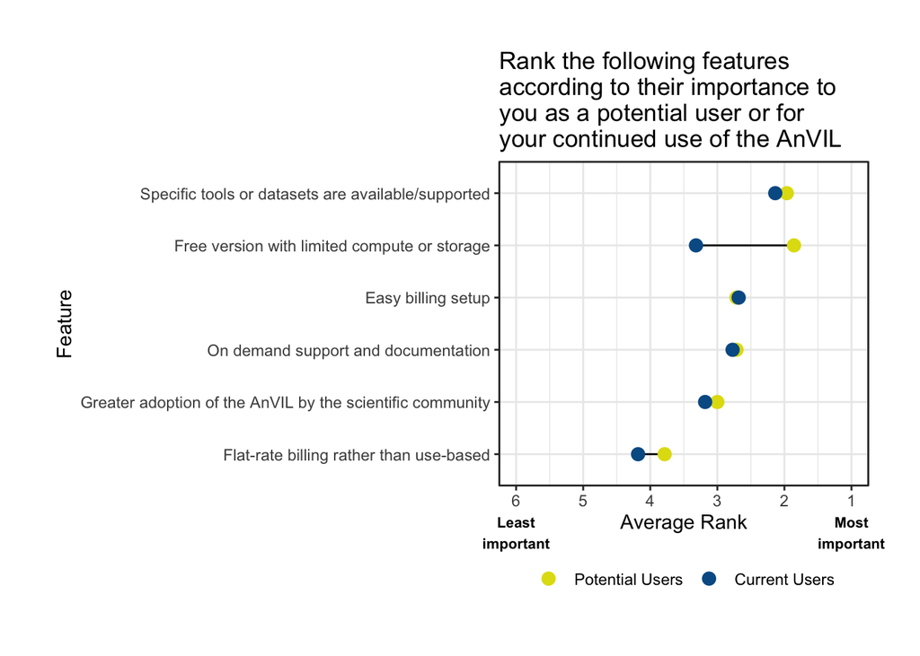

## Preferences: Training Workshop Modality

**Takeaway:**

### Prepare and plot the data

**Description of variable definitions and steps for preparing the data**

**Description of variable definitions and steps for plotting the dumbbell plot**

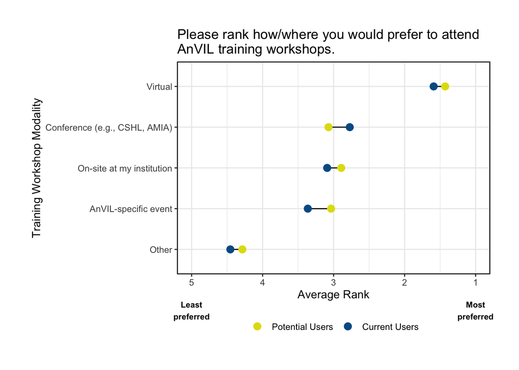

## Returning User Specific: Likely to recommend?

**Takeaway:**

## Returning User Specific: Number of years of use

**Takeaway:**

## Returning User Specific: Foreseeable Computational Needs

**Takeaway:**